# Normal Likelihood Ratio

Christopher Gillies

2/8/2018

# Model

Normal distribution density function
$$\begin{equation}
f(x|\mu,\sigma^2) = \frac{1}{\sqrt{2 \pi \sigma^2}} \exp \left [ -\frac{(x-\mu)^2}{2\sigma^2} \right ]
\end{equation}$$

$H_0: \mu_0 = \mu_1$

$H_1: \mu_0 \ne \mu_1$

Assume we have $n_0$ observations in group 0 and $n_1$ observations in group 1 and given the group status the observations are IID with the same variance . Under $H_0$ we have the following likelihood:

$$\begin{equation}
L(Y|H_0) = \left ( \frac{1}{\sqrt{2 \pi \sigma^2}} \right )^{n_0} \left ( \frac{1}{\sqrt{2 \pi \sigma^2}} \right )^{n_1} \exp \left [ -\sum_{i=0}^{n_0}\frac{(Y_{0i}- \hat \mu_{0+1})^2}{2 \sigma^2} \right ] \exp \left [ -\sum_{i=0}^{n_1}\frac{(Y_{1i}- \hat \mu_{0+1})^2}{2 \sigma^2} \right ]
\end{equation}$$
$$\begin{equation}
L(Y|H_0) = \left ( \frac{1}{\sqrt{2 \pi \sigma^2}} \right )^{n} \exp \left [ -\sum_{i=0}^{n}\frac{(Y_{i}- \hat \mu_{0+1})^2}{2 \sigma^2} \right ]
\end{equation}$$

where $Y_{0i}$ is the value of the $i$th example from group 0, the same for $Y_{1i}$, $\sigma^2$ is the variance is the overall variance and $\mu_{0+1}$ is the pooled mean estimate.

$$\begin{equation}
L(Y|H_1) = \left ( \frac{1}{\sqrt{2 \pi \sigma^2}} \right )^{n_0} \left ( \frac{1}{\sqrt{2 \pi \sigma^2}} \right )^{n_1} \exp \left [ -\sum_{i=0}^{n_0}\frac{(Y_{0i}- \hat \mu_{0})^2}{2 \sigma^2} \right ] \exp \left [ -\sum_{i=0}^{n_1}\frac{(Y_{1i}- \hat \mu_{1})^2}{2 \sigma^2} \right ]
\end{equation}$$
$$\begin{equation}
L(Y|H_1) = \left ( \frac{1}{\sqrt{2 \pi \sigma^2}} \right )^{n} \exp \left [ -\sum_{i=0}^{n_0}\frac{(Y_{0i}- \hat \mu_{0})^2}{2 \sigma^2} \right ] \exp \left [ -\sum_{i=0}^{n_1}\frac{(Y_{1i}- \hat \mu_{1})^2}{2 \sigma^2} \right ]
\end{equation}$$

where $\hat \mu_{0}$ is the MLE of the mean of group 0, and $\hat \mu_{1}$ is the MLE of the mean of group 1.

$$\begin{equation}
\frac{ L(Y|H_0) }{L(Y|H_1)} = \frac { \exp \left [ \frac{-1}{2\sigma^2} \sum_{i=0}^{n}(Y_{i}- \hat \mu_{0+1})^2 \right ] } { \exp \left [ \frac{-1}{2\sigma^2} \sum_{i=0}^{n_0}(Y_{0i}- \hat \mu_{0})^2 \right ] \exp \left [ \frac{-1}{2\sigma^2} \sum_{i=0}^{n_1}(Y_{1i}- \hat \mu_{1})^2 \right ] } = \frac{ \exp( \frac{-n \hat \sigma_{0+1}^2}{2\sigma^2} ) } { \exp(\frac{-n_0 \hat \sigma_{0}^2 - n_1 \hat \sigma_{1}}{2\sigma^2}) }
\end{equation}$$
Taking the log we have
$$\begin{equation}
-2 \log \left ( \frac{ L(Y|H_0) }{L(Y|H_1)} \right ) = -2 \left ( \frac{n_0 \hat \sigma_{0}^2 + n_1 \hat \sigma_{1}}{2\sigma^2} - \frac{n \hat \sigma_{0+1}^2}{2\sigma^2} \right ) = \frac{-1}{\sigma^2} \left ( n_0 \hat \sigma_{0}^2 + n_1 \hat \sigma_{1} - n \hat \sigma_{0+1}^2 \right )
\end{equation}$$

We can estimate $\sigma^2$ using a pooled variance estimate $S_p^2$.

$$\begin{equation}
S_p^2=\frac{ (n_0 - 1) S_0^2 + (n_1 - 1) S_1^2} { n_0 + n_1 - 2}
\end{equation}$$

where $S_0^2$ and $S_1^2$ are sample variance estiamtes for group 0 and group 1.

$$\begin{equation}
-2 \log \left ( \frac{ L(Y|H_0) }{L(Y|H_1)} \right ) \sim \chi^2_1
\end{equation}$$

```r
pop.var <- function(x) var(x) * (length(x)-1) / length(x)

pooled.var <- function(s0,s1) {
  s0.var = var(s0)
  s1.var = var(s1)

  n0 = length(s0)
  n1 = length(s1)

  ( (n0 - 1) * s0.var + (n1 - 1) * s1.var ) / (n0 + n1 - 2)
}

lrt = function(s0,s1) {
  pooled = c(s0,s1)
  n = length(pooled)
  n0 = length(s0)
  n1 = length(s1)
  pooled.var.est = pooled.var(s0,s1)

  chi =  -1/pooled.var.est * ( n0 * pop.var(s0) + n1 * pop.var(s1) - n * pop.var(pooled)  )
  pchisq(chi,df=1,lower.tail=F)
}

lrt.simple = function(s0,s1) {
  pooled = c(s0,s1)
  pooled.mean = mean(pooled)
  pooled.var.est = pooled.var(s0,s1)
  s0.mean = mean(s0)
  s1.mean = mean(s1)

  chi = -2 * (sum(dnorm(pooled,mean=pooled.mean,sd=sqrt(pooled.var.est),log = T)) -
    sum(dnorm(s0,mean=s0.mean,sd=sqrt(pooled.var.est),log = T)) - sum(dnorm(s1,mean=s1.mean,sd=sqrt(pooled.var.est),log = T)))
  pchisq(chi,df=1,lower.tail=F)
}
```

## Compare LRT simple verus formula

```r
n0 = 100
n1 = 100
s0 = rnorm(n0,sd=2)
s1 = rnorm(n1,sd=2)
lrt.simple(s0,s1)
```

```
## [1] 0.07897393
```

```r
lrt(s0,s1)
```

```
## [1] 0.07897393
```

## Check Type I Error

```r
p_lrts = c()
p_ts = c()
nsim = 1000
n0 = 100
n1 = 100
p_lms = c()
for(i in seq(1,nsim)) {
  s0 = rnorm(n0,sd=2)
  s1 = rnorm(n1,sd=2)
  y = c(s0,s1)
  x = c( rep(1,length(s0)), rep(0,length(s1)) )
  p_ts = c(p_ts,  t.test(s0,s1,var.equal = TRUE)$p.val)
  p_lrts = c(p_lrts,  lrt.simple(s0,s1))
  null = lm(y ~ 1)
  alt = lm(y ~ x)
  p_lms = c(p_lms, anova(null,alt,test="Chisq")[2,5])
}

sum(p_ts < 0.05) / nsim
```

```
## [1] 0.051
```

```r
sum(p_lms < 0.05 ) / nsim
```

```
## [1] 0.053
```

```r
sum(p_lrts < 0.05) / nsim
```

```
## [1] 0.053
```

## Check Power

```r
p_lrts = c()
p_ts = c()
nsim = 1000
n0 = 100
n1 = 100
p_lms = c()
for(i in seq(1,nsim)) {
  s0 = rnorm(n0)
  s1 = rnorm(n1,mean=0.2)
  y = c(s0,s1)
  x = c( rep(1,length(s0)), rep(0,length(s1)) )
  p_ts = c(p_ts,  t.test(s0,s1)$p.val)
  p_lrts = c(p_lrts,  lrt(s0,s1))
  null = lm(y ~ 1)
  alt = lm(y ~ x)
  p_lms = c(p_lms, anova(null,alt,test="Chisq")[2,5])
}

sum(p_ts < 0.05) / nsim
```

```
## [1] 0.286
```

```r
sum(p_lms < 0.05 ) / nsim
```

```
## [1] 0.289
```

```r
sum(p_lrts < 0.05) / nsim
```

```
## [1] 0.289
```

So we did all that stuff and got the same thing as a t-test and linear regression! What was the point? To learn how to do a likelihood ratio test so that we can then do a Bayes factor.

# Bayes Factor Based Approach

$$\frac{p(H_1 | y)}{p(H_0 | y)} = \frac{p(y|H_1) }{p(y|H_0) } \frac{p (H_1 )}{p (H_0)}$$

The posterior odds = Bayes Factor $\times$ prior odds. The Bayes Factor is $\frac{p(y|H_1) )}{p(y|H_0) }$.

To compute the Bayes Factor we need $p(y|H_0)$ and $p(y|H_1)$, where these are the probabilities of the data given the corresponding models.

$$\begin{equation}
p(y) = \int p(y|\theta) p(\theta) d\theta
\end{equation}$$

This integral can be challenging to compute. But if we can compute the normalizing constant for the posterior distribution ($p(\theta|y)$), the we can compute $p(y)$ without the need to compute the integral.

$$\begin{equation}
p(\theta | y) \propto p(y|\theta) p(\theta) = p(y,\theta)
\end{equation}$$
$$\begin{equation}
p(\theta | y) p(y) = p(y,\theta) = p(y|\theta) p(\theta)
\end{equation}$$
$$\begin{equation}
p(y) = \frac{p(y|\theta) p(\theta)}{p(\theta | y)}
\end{equation}$$

So if we know the posterior distribution of $\theta$ given $y$, then we can compute $p(y)$ using any value of $\theta$.

## Normal prior

Assume we have $n$ observations, and the prior distribution of $\theta$ is $N(\theta;\mu_0,\tau^2_0)$.
$$\begin{equation}
p(\theta | y) \propto p(\theta)p(y|\theta) = p(\theta) \prod_{i=1}^{n} p(y_i|\theta)
\end{equation}$$
$$\begin{equation}
\propto \exp \left ( -\frac{1}{2\tau_0^2} (\theta-\mu_0)^2 \right ) \exp \left ( \prod_{i=1}^n ( -\frac{1}{2\sigma^2} (y_i-\theta)^2 \right )
\end{equation}$$
$$\begin{equation}
\propto \exp \left ( -\frac{1}{2} \left ( \frac{1}{\tau_0^2} (\theta-\mu_0)^2 + \frac{1}{\sigma^2} \sum_{i=1}^n(y_i-\theta)^2 \right ) \right )
\end{equation}$$

It can be shown that
$$p(\theta | y_1, ..., y_n) = p(\theta | \bar y) = N(\theta | \mu_n, \tau_n^2)$$

$$\mu_n = \frac{\frac{1}{\tau_0^2}\mu_0 + \frac{n}{\sigma^2}\bar y}{ \frac{1}{\tau_0^2} + \frac{n}{\sigma^2}}$$

$$\frac{1}{\tau_n^2} = \frac{1}{\tau_0^2} + \frac{n}{\sigma^2}$$

### Verify they ways we can compute $p(y)$

$$p(y) = \frac{p(y|\theta) p(\theta)}{p(\theta | y)} = \int p(y|\theta) p(\theta) d\theta$$

#### Code to compute the likelihood and posterior

```r
likelihood = function(y,known_mean,known_var,log=FALSE) {
  compute = function(mu) {
    res = dnorm(y,mean=mu,sd = sqrt(known_var),log=log)
    if(!log) {
      prod(res)
    } else {
      sum(res)
    }
  }

  #if there are multiple means return a likelihood for each 1
  if(length(known_mean) > 1) {
    sapply(known_mean, function(mu) {
      compute(mu)
    })
  } else {
    compute(known_mean)
  }
}

prior = function(mu,prior_mean=0,prior_var=1,log=FALSE) {
  dnorm(mu,prior_mean,sqrt(prior_var),log=log)
}


joint = function(y,mu,known_var,prior_mean,prior_var,log=FALSE) {
  if(!log) {
    likelihood(y,mu,known_var,log=log) * prior(mu,prior_mean,prior_var,log)
  } else {
    likelihood(y,mu,known_var,log=log) + prior(mu,prior_mean,prior_var,log)
  }
}

posterior = function(y,mu,known_var,prior_mean,prior_var,log=FALSE) {
  mean_n = 1/prior_var * prior_mean + length(y) / known_var * mean(y)
  mean_n = mean_n / (1/prior_var + length(y)/known_var)
  sd_n = sqrt( 1/(1/prior_var + length(y)/known_var)  )
  dnorm(mu,mean=mean_n,sd=sd_n,log=log)
}
```

#### Example

The posterior and joint should look the same and they should have a constant proportion between them so we can compute $p(y)$ using any value of $\theta$.

```r
joint(y=1,mu=c(-2,-1,0,1,2),1,0,1)
```

```
## [1] 0.0002392798 0.0130642333 0.0965323526 0.0965323526 0.0130642333
```

```r
posterior(y=1,mu=c(-2,-1,0,1,2),1,0,1)
```

```
## [1] 0.001089142 0.059465145 0.439391289 0.439391289 0.059465145
```

```r
joint(y=1,mu=c(-2,-1,0,1,2),1,0,1) / posterior(y=1,mu=c(-2,-1,0,1,2),1,0,1)
```

```
## [1] 0.2196956 0.2196956 0.2196956 0.2196956 0.2196956
```

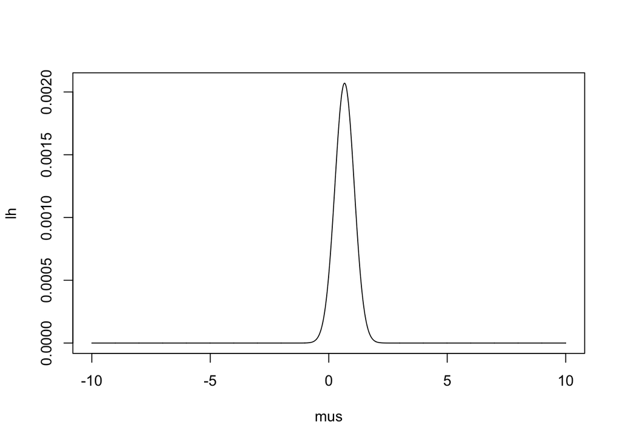

```r
mus = seq(-10,10,0.01)
lh = joint(y=c(0,1,1,1,1),mu=mus,1,0,1)
plot( mus,lh,type="l")
```

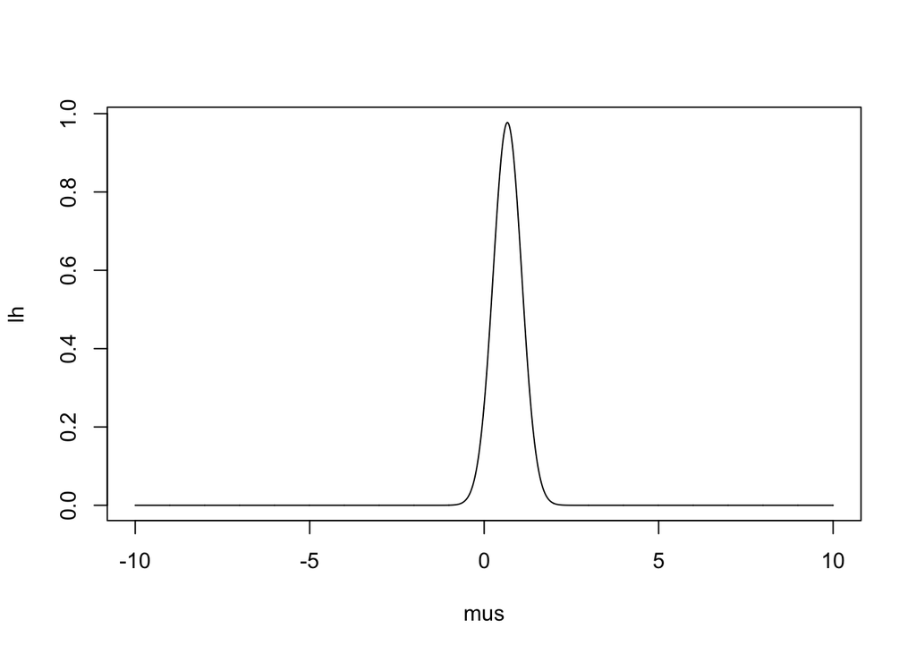

```r
mus = seq(-10,10,0.01)
lh = posterior(y=c(0,1,1,1,1),mu=mus,1,0,1)
plot( mus,lh,type="l")
```

```r
#THIS SHOULD BE 1
integrate(function(mu) {
  posterior(y=c(0,1,1,0,1),mu=mu,1,0,1)
},-10,10)
```

```
## 1 with absolute error < 1.3e-07
```

```r
#THESE SHOULD EQUAL
integrate(function(mu) {
  joint(y=c(0,1,1,0,1),mu=mu,1,0,1)
},-10,10)
```

```
## 0.00194874 with absolute error < 0.00011
```

```r
joint(y=c(0,1,1,0,1),mu=1,1,0,1) / posterior(y=c(0,1,1,0,1),mu=1,1,0,1)
```

```
## [1] 0.00194874
```